# Confounding Versus Effect Modification

Author: Benjamin Chase  
Last Edited: June 7, 2022  
Length: 10 min read

## Table of contents

1. Causal Effects
2. Confounding
   - Example
3. Effect Modification
   - Example
4. Summary

## What is a Causal Effect?

People often want to know if an event causes something to happen. For instance, you might want to know if undergoing surgery will cause you to live a longer life. This is typically referred to as a *causal effect* because an event (surgery) causes something to happen (you live a longer life). Causal relationships can be represented by a *directed acyclic graph*, or DAG[^1] for short. Check out the sample DAG below[^2]:

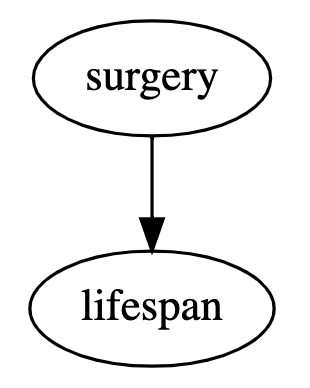

DAG showing that undergoing surgery has a direct causal effect on lifespan

The arrow going from surgery to lifespan says, in DAG language, that undergoing surgery has a *direct* causal effect on an individual’s lifespan. The DAG does not say whether the effect is positive or negative, only that some causal effect exists. Causal effects can also be *indirect*. Take a look at an alternative DAG below:

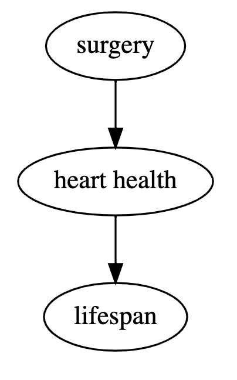

DAG showing that undergoing surgery has an indirect causal effect on lifespan which is mediated by heart health

This DAG says that undergoing surgery has a direct causal effect on heart health, and heart health has a direct causal effect on lifespan. In this DAG, undergoing surgery does not have a direct causal effect on an individual’s lifespan, but an indirect causal effect *mediated by heart health*.

The existence of causal effects is often the focus of research. For instance, scientists likely wanted to know whether or not the COVID-19 vaccine had a causal effect (direct or indirect) on patient outcomes. Questions like these are typically answered using a *outcome regression model*[^3] in which an outcome (e.g., lifespan) is modeled as a function of predictors (e.g., vaccine status, obesity, age, etc.). Causal effects estimated by regression models are heavily dependent on two things:

1. Which predictors are used in the model.
2. Which data the model learns from.

If you miss on either point when conducting your analysis, your conclusions will likely be wrong. These dependencies are the reason that recognizing the difference between *confounding* and *effect modification* is crucial to properly estimate causal effects.

## What is Confounding?

I think of confounding as a characteristic a model can have due to bad choice of predictors. A model should never have confounding when estimating causal effects because any estimates will be *biased* (this is a fancy way to say wrong).

A model has confounding when two conditions are met:

1. There is a *common cause* of the outcome (e.g., lifespan) and the thing whose effect we want to estimate (e.g., surgery). This common cause is called a *confounder*.
2. The confounder is **not** properly handled.

In short, confounders almost always exist in data, and models are plagued with confounding when confounders are not properly handled. Take a look at the DAG below to see an example of confounding:

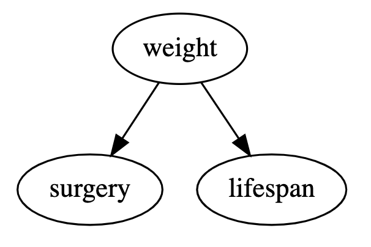

DAG showing that weight is a common cause of surgery on lifespan, and therefore a confounder when estimating the causal effect of surgery on lifespan

There are three features in this DAG which confirm the presence of a confounder:

1. There is an arrow going from weight to surgery, which implies an individual’s weight has a direct causal effect on whether they undergo surgery.
2. There is an arrow going from weight to lifespan, which implies an individual’s weight has a direct causal effect on their lifespan.
3. There is **not** an arrow going from surgery to lifespan, which implies undergoing surgery does **not** have a direct nor indirect causal effect on their lifespan.

Weight is a confounder and needs to be handled properly to estimate the causal effect of undergoing surgery on lifespan. There are many ways to do this[^4] [^5] [^6] (matching, IP weighting, standardization, g-estimation) but a common method is *outcome regression*, which requires the confounder to be included as a predictor in a linear or logistic regression model. If the confounder is not included as a predictor in the model, we have a model with confounding and a biased estimate of the causal effect.

### Example of Confounding

Let’s look at some sample data to understand how failing to handle confounders can lead to biased conclusions. Imagine a population in which only people over a certain weight are eligible for surgery, heavier people tend to have shorter lifespans, and undergoing surgery does **not** change an individual’s lifespan. This imaginary universe reflects the previous DAG with weight as a confounder.

We’ll start with some random data that captures individuals’ weights in kilograms:

```python
weight = stats.norm.rvs(loc = 100, scale = 20, size = 1_000)
```

Next, we’ll create surgery data such that only people who weigh over 100 kilograms receive surgery:

```python
surgery = weight > 100
```

Finally, we’ll create lifespan data such that heavier people have shorter lifespans:

```python
lifespan = 100 - weight/10
```

In our sample data, weight has a direct causal effect on both surgery and lifespan, but surgery does not have a causal effect on weight. We could build a linear regression model to test whether or not undergoing surgery has a causal effect on lifespan. Let’s see what happens if we do not properly handle the confounder, weight, and only include surgery as a predictor in the model:

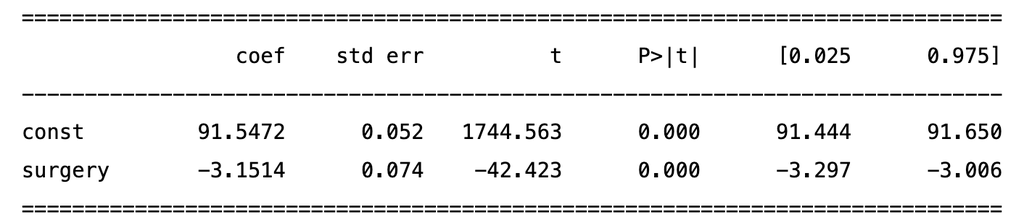

Estimates from a linear regression model with confounding which suggest a biased causal effect of undergoing surgery on lifespan

We would estimate a significant and negative causal effect of surgery on lifespan, even though none exists in the data! Remember, we created our data such that **only** weight impacts lifespan. Failing to include weight as a predictor here would incorrectly lead us to the conclusion that undergoign surgery reduces an individual’s lifespan. Now, let’s see what changes if we properly handle the confounder, weight, and include it as a predictor in the linear regression model:

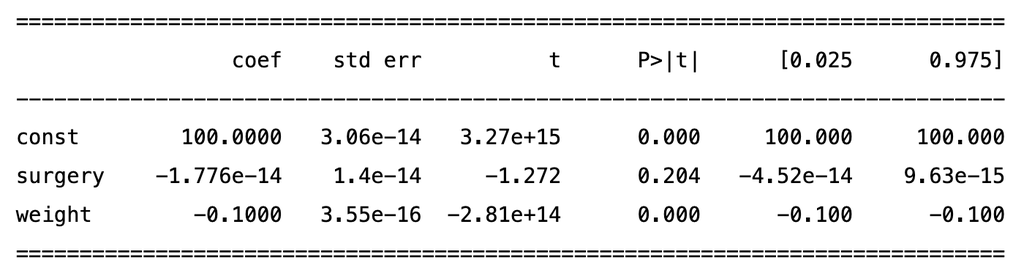

Estimates from a linear regression model without confounding, which correctly estimates the causal effects of weight and surgery on lifespan

Now that we properly handled the confounder, we do not estimate a significant causal effect of surgery on lifespan, and correctly detect that weight has a significant negative causal effect on lifespan. Failing to recognize confounding in a model can lead to finding causal effects that don’t exist, and vice-versa. This is also referred to as *omitted variable bias* in some fields.

## What is Effect Modification?

While I think of confounding as a problematic characteristic of a model, I think of effect modification as a neutral characteristic of data. Models do not have effect modification, but real-world processes do. For instance, it is possible that undergoing surgery increases an individual’s lifespan for males but not for females. This is an example of effect modification because the surgery’s causal on lifespan *depends on biological sex*. I find the traditional DAG design for effect modification a bit unintuitive, so check out the DAG below for a (hopefully) clearer diagram:

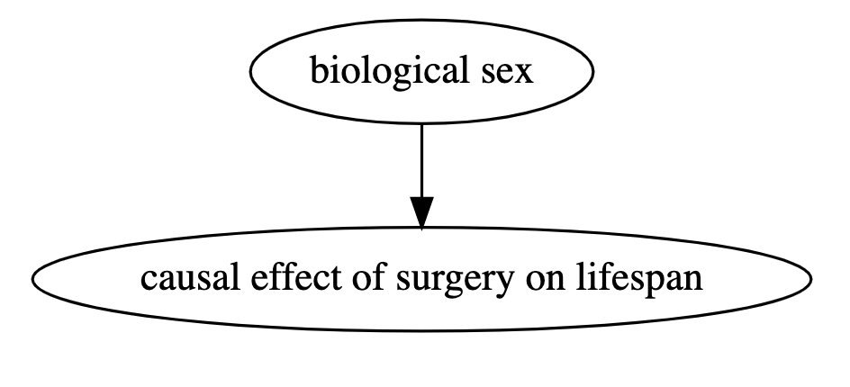

DAG showing that biological sex is a direct effect modifier

Similar to direct and indirect causal effects, there can be direct and indirect effect modification. For instance, an individual’s biological sex might have a causal effect on testosterone, which directly modifies the effect of surgery. In the DAG below, biological sex is an *indirect effect modifier* while testosterone is a *direct effect modifier*:

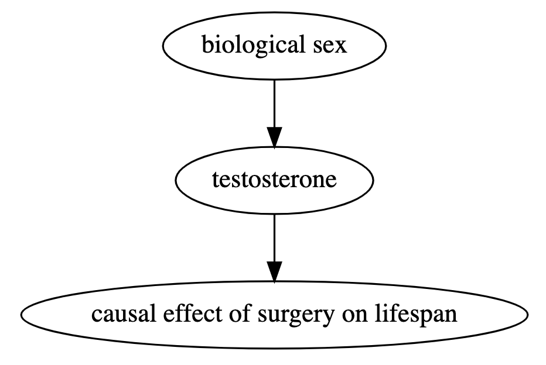

DAG showing that biological sex is an indirect effect modifier mediated by testosterone

Unlike confounding, effect modification is not a boogeyman that threatens to invalidate your model and estimated causal effect. Instead, it can cripple the conclusion of an *imprecise question*. Think about our original question:

- Does undergoing surgery have a causal effect on lifespan?

Unfortunately, this question is too vague to properly estimate causal effects. Instead, we must be more precise. For instance, we could ask:

- Does undergoing surgery have a causal effect on lifespan **for men**?

This is an improvement because our new question better specifies a population (there is no end to how precise a causal question can be, but we’ll stop here for now). Let’s walk through an example to see how effect modification can cause problems.

### Example of Effect Modification

Once again, let’s look at some sample data. We’ll start with a randomly distributed surgery:

```python
surgery = np.array([random.randint(0, 2) for _ in range(1_000)])
```

Next, we’ll split the data into two groups, males and females:

```python
male = np.concatenate([np.zeros(500), np.ones(500)], axis = 0)
```

Finally, we’ll make an outcome variable, lifespan. Lifespan is made such that surgery has a *positive* causal effect for males and a *negative* causal effect for females. Therefore, biological sex is a direct effect modifier.

```python
lifespan = 75 + 25*surgery*male - 25*surgery*(1 - male)
```

Our original question was to find out whether or not undergoing surgery will increase an individual’s lifespan. There are no confounders here because surgery was *randomly assigned*, so we can construct an outcome regression model with surgery as the only predictor. Let’s see what happens:

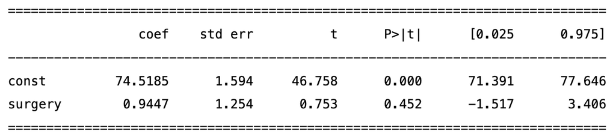

Estimates from a linear regression model using data for the entire population

We would conclude that surgery does not have a significant causal effect on lifespan in the *entire population*. On average, this is true. However, this is not true for any *individual* because the surgery has equal and opposite effects for men and women, whom are evenly distributed in the population. Due to effect modification paired with our imprecise question, the causal effects canceled out! Let’s see what happens when we restrict our model to data for males; this is analogous to forming a more precise question:

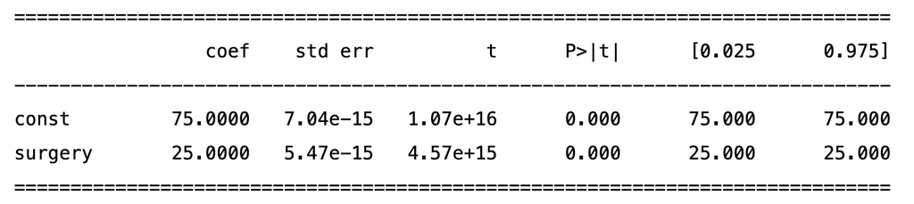

With a more precisely specified population (only males), we find a significant and positive causal effect of surgery on lifespan. We can see the same for a population with all females:

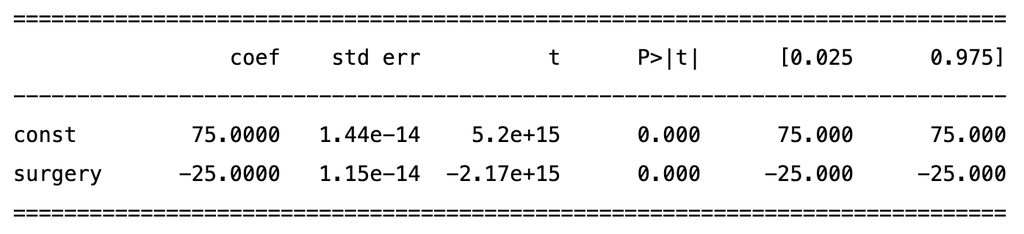

Estimates from a linear regression model using data for the female population

for whom surgery has a significant and negative causal effect on lifespan. To be clear, sex is **not** a confounder. It **should not** be controlled for in the same way as a confounder, such as by including it as a predictor in our outcome regression model. Let’s see what happens if we do that:

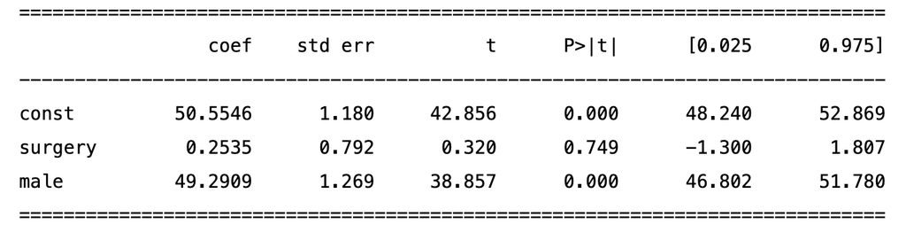

Estimates from a linear regression model with an effect modifier treated like a confounder

Once again, we do not estimate a significant causal effect of surgery on lifespan, although it is significant within the respective male and female populations. We estimate a significant causal effect of sex on lifespan, however, this is **not** true if nobody in the population undergoes surgery. The problems associated with an effect modifier **cannot** be solved by modifying the model, like we did to prevent confounding. Instead, effect modification requires a more precise question to avoid misleading conclusions.

## Summary

I think of confounding as a problematic characteristic of a model that occurs when a confounder is not properly handled. If confounding is not corrected, causal effects cannot be estimated. Sometimes it is impossible to properly handle confounders, which is often due to a lack of data. Techniques, such as *instrumental variables*, exist to combat this problem, but they all have limitations.

I think of effect modification as a neutral characteristic of data which is associated with real-world processes. Effect modification cannot be prevented and should **not** be treated the same way as confounding. If you are working with a large number of variables, there will almost always be effect modification to some extent. The best way to avoid misleading conclusions due to effect modifiers is to make your question as precise as possible. For example, consider the two possible questions:

1. Do email reminders make people save more money?
2. Does a daily email reminder sent at 10:00PM for 3 weeks, make married women, aged 25-34, living in New York City, significantly increase their contributions to their IRA?

Confounding and effect modification are two important and distinct features that should be understood when interpreting reported effects and doing your own research.

**Note**: All source code written for this post is available in a Python notebook here: https://colab.research.google.com/drive/1Aln4jJfUUQXvK8Fnp75aAMv-utTYoYKp?usp=sharing

[^1]: Directed Acyclic Graphs (DAGs) can be quite complicated when used in practice. You can read more about them and find some additional resources here: https://cran.r-project.org/web/packages/ggdag/vignettes/intro-to-dags.html
[^2]: I strongly recommend the following Python package for drawing and working with DAGs; it’s the one I used in this post: https://github.com/ijmbarr/causalgraphicalmodels
[^3]: Check out this book for a Bayesian approach to linear and logistic regression models: https://www.amazon.com/dp/B09RW8BYQR/ref=cm_sw_em_r_mt_dp_EJDSGXMTW6J9Z2TTZASQ
[^4]: Check out this book for a deep dive into causal inference techniques: https://mixtape.scunning.com
[^5]: Another resource for causal inference techniques: https://theeffectbook.net
[^6]: A more mathematical resource for causal inference techniques: https://www.hsph.harvard.edu/miguel-hernan/causal-inference-book/